# Tree inference for bulk DNA-seq with Metropolis-Hasting samping or Hybrid MCMC sampling

Yuanhua Huang

Note: in PASTRI, importance sampling is used to integrate the allelic frequency vector. When there are multiple trees, the proposal may not explore all space for each tree.

Here, we try to use the Metropolis-Hasting algorithm to sample the tree as a discrete variable and the clonal fraction. For the discrete variable (label of the tree), we design a transition matrix and for the clonal fraction, we use a logit-normal distribution.

** Note, we could adptive the proposal for the transistion matrix by its empirical samples.**

TODO: 1) using EM as a good initialzation 2) check all EM ordering with tree compatibility

EM also need good initialization, otherwise, it ends up a local optima. Better try multiple short trials

# 1 Load example data

Five clones with 8 samples. The simulaiton truth is tree 5 for 8 samples, but by using a single sample, we may obtain different tree.

```r
library(bisctree)
A <- as.matrix(read.table(system.file("example", "example_A.txt",
                                      package = "bisctree"))[,1])
D <- as.matrix(read.table(system.file("example", "example_D.txt",
                                      package = "bisctree"))[,1])

tree_file <- system.file("PPMatrix", "Matrix5.txt", package = "bisctree")
dat_tmp <- read.table(tree_file, skip = 1)
B_list <- list()
for (it in seq_len(nrow(dat_tmp) / ncol(dat_tmp))) {
  first_idx <- ncol(dat_tmp) * (it - 1) + 1
  last_idx <- ncol(dat_tmp) * it
  B_list[[it]] <- as.matrix(dat_tmp[first_idx:last_idx, ])
}
```

```r
B_list
```

```
## [[1]]
##   V1 V2 V3 V4 V5
## 1  1  1  1  1  1
## 2  0  1  1  1  1
## 3  0  0  1  1  1
## 4  0  0  0  1  1
## 5  0  0  0  0  1
##
## [[2]]
##    V1 V2 V3 V4 V5
## 6   1  1  1  1  1
## 7   0  1  1  1  1
## 8   0  0  1  1  1
## 9   0  0  0  1  0
## 10  0  0  0  0  1
##
## [[3]]
##    V1 V2 V3 V4 V5
## 11  1  1  1  1  1
## 12  0  1  1  1  1
## 13  0  0  1  1  0
## 14  0  0  0  1  0
## 15  0  0  0  0  1
##
## [[4]]
##    V1 V2 V3 V4 V5
## 16  1  1  1  1  1
## 17  0  1  1  1  0
## 18  0  0  1  1  0
## 19  0  0  0  1  0
## 20  0  0  0  0  1
##
## [[5]]
##    V1 V2 V3 V4 V5
## 21  1  1  1  1  1
## 22  0  1  1  1  1
## 23  0  0  1  0  0
## 24  0  0  0  1  0
## 25  0  0  0  0  1
##
```

[output cut: 16 more lines]

```
## [[8]]
##    V1 V2 V3 V4 V5
## 36  1  1  1  1  1
## 37  0  1  1  0  0
## 38  0  0  1  0  0
## 39  0  0  0  1  0
## 40  0  0  0  0  1
##
## [[9]]
##    V1 V2 V3 V4 V5
## 41  1  1  1  1  1
## 42  0  1  0  0  0
## 43  0  0  1  0  0
## 44  0  0  0  1  0
## 45  0  0  0  0  1
```

# 2 Test EM algorithm for binomial mixture model

```r
rt_mix <- mixBinom(A[,1], D[,1], 5, tol = 1e-5)
```

```
## [1] 10
```

```r
t(rt_mix$p * 2)
```

```
##           [,1]      [,2]      [,3]      [,4]      [,5]
## [1,] 0.6839859 0.8035588 0.1189896 0.4675839 0.4675817
```

```r
#options(digits=2)

n_init = 20
logLik_all <- rep(0, n_init)
p_all <- matrix(0, nrow = n_init, ncol = 5)
for (i in seq_len(n_init)) {
    #rt_mix <- mixBinom(A, D, 5)
    rt_mix <- mixBinom(A[,1], D[,1], 5, max_iter = 500)

    logLik_all[i] <- rt_mix$log_like
    p_all[i, ] <- t(rt_mix$p * 2)
}
```

```
## [1] 10
## [1] 10
## [1] 10
## [1] 10
## [1] 10
## [1] 10
## [1] 10
## [1] 10
## [1] 10
## [1] 10
## [1] 10
## [1] 10
## [1] 10
## [1] 10
## [1] 10
## [1] 10
## [1] 10
## [1] 10
## [1] 10
## [1] 10
```

```r
t(p_all[which.max(logLik_all), ])
```

```
##           [,1]      [,2]      [,3]      [,4]       [,5]
## [1,] 0.8035795 0.4677089 0.6840237 0.1854213 0.01277954
```

```r
t(logLik_all)
```

```
##           [,1]      [,2]      [,3]      [,4]      [,5]      [,6]      [,7]
## [1,] -237.7757 -237.7757 -237.7757 -209.3267 -237.7757 -237.7757 -237.7757
##           [,8]      [,9]     [,10]     [,11]     [,12]     [,13]     [,14]
## [1,] -237.7757 -237.7757 -237.7757 -239.0538 -237.7757 -237.7757 -237.7757
##          [,15]     [,16]     [,17]     [,18]     [,19]     [,20]
## [1,] -210.6029 -237.7757 -237.7757 -237.7757 -237.7757 -237.7757
```

# 3 Test MH sampling

```r
# library(mvtnorm)
# source("~/MyGit/cardelino/R/bulk_tree_MH.R")

rt_samp <- bulk_tree_MH(A[,1], D[,1], B_list, n_iter = 5000, sigma = 0.015)
#rt_samp <- bulk_tree_MH(A[,1], D[,1], list(B_list=B_list[[3]]), n_iter=5000, sigma=0.015)
```

```r
library(ggpubr)
table(rt_samp$tree_all)
```

```
##
##    1    2    3    4    6
## 1217 1442 1260 1080    1
```

```r
mean(rt_samp$accept_all)
```

```
## [1] 0.7594
```

```r
t(rt_samp$accept_all[1:40])
```

```
##      [,1] [,2] [,3] [,4] [,5] [,6] [,7] [,8] [,9] [,10] [,11] [,12] [,13]
## [1,]    1    2    0    1    1    0    1    0    0     0     1     0     0
##      [,14] [,15] [,16] [,17] [,18] [,19] [,20] [,21] [,22] [,23] [,24]
## [1,]     0     1     1     0     0     0     0     2     0     0     0
##      [,25] [,26] [,27] [,28] [,29] [,30] [,31] [,32] [,33] [,34] [,35]
## [1,]     0     0     1     0     0     0     1     1     0     1     2
##      [,36] [,37] [,38] [,39] [,40]
## [1,]     1     0     0     1     0
```

```r
idx <- which.max(rt_samp$P_all)
t(B_list[[1]] %*% rt_samp$Psi_all[[idx]])
```

```
##              1         2         3       4          5
## [1,] 0.7540607 0.6778191 0.4765573 0.20042 0.01382164
```

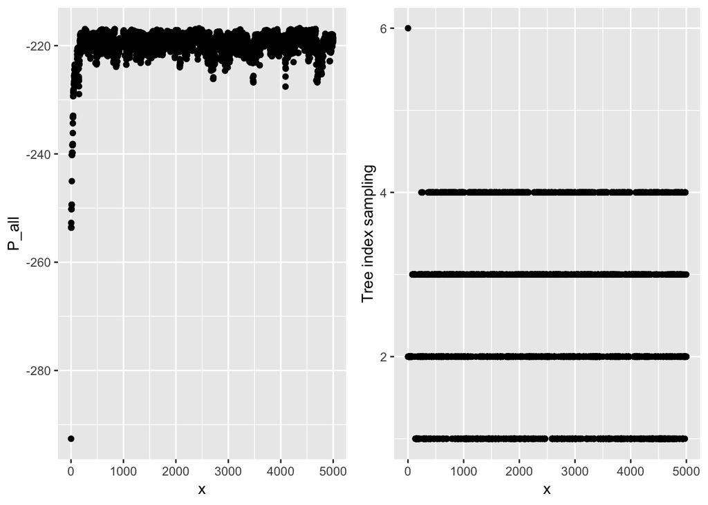

```r
dat_tmp <- data.frame(x=seq_len(length(rt_samp$P_all)), P_all=rt_samp$P_all,
                      tree_all=rt_samp$tree_all)

options(repr.plot.width=6, repr.plot.height=2)
fig1 <- ggplot(dat_tmp, aes(x=x, y=P_all)) + geom_point()
fig2 <- ggplot(dat_tmp, aes(x=x, y=tree_all)) + geom_point() + ylab("Tree index sampling")
ggarrange(fig1, fig2)
```

```r
idx <- which.max(rt_samp$P_all)
t(rt_samp$Psi_all[[idx]])
```

```
##            [,1]      [,2]      [,3]      [,4]       [,5]
## [1,] 0.07624156 0.2012618 0.2761373 0.1865983 0.01382164
```

```r
t(B_list[[rt_samp$tree_all[idx]]] %*% rt_samp$Psi_all[[idx]])
```

```
##             16        17        18        19         20
## [1,] 0.7540607 0.6639975 0.4627356 0.1865983 0.01382164
```

```r
Psi_avg = rt_samp$Psi_all[[1]]
Psi_avg[,] = 0
for(i in seq(2001:5000)){
    Psi_avg <- Psi_avg + (B_list[[5]] %*% rt_samp$Psi_all[[i]])
}
t(Psi_avg / 3001)
```

```
##             21        22        23        24         25
## [1,] 0.7594426 0.6640048 0.2754653 0.1831092 0.01923806
```

0.855, 0.710, 0.463, 0.153, 0.025

0.85540178, 0.70968325, 0.46347363, 0.15341701, 0.02520374

# 4 Test HHybrid MCMC sampling

```r
rt_samp <- bulk_tree_hybrid(A[,1], D[,1], B_list, n_iter=5000, sigma=0.015)
```

```r
library(ggpubr)

table(rt_samp$tree_all)
```

```
##
##    1    2    3    4
## 1350 1245 1331 1074
```

```r
mean(rt_samp$accept_all)
```

```
## [1] 0.4292
```

```r
t(rt_samp$accept_all[1:40])
```

```
##      [,1] [,2] [,3] [,4] [,5] [,6] [,7] [,8] [,9] [,10] [,11] [,12] [,13]
## [1,]    1    1    0    0    1    0    0    1    1     1     0     1     0
##      [,14] [,15] [,16] [,17] [,18] [,19] [,20] [,21] [,22] [,23] [,24]
## [1,]     0     1     0     1     0     0     1     0     0     1     1
##      [,25] [,26] [,27] [,28] [,29] [,30] [,31] [,32] [,33] [,34] [,35]
## [1,]     1     0     0     0     0     1     0     1     0     0     0
##      [,36] [,37] [,38] [,39] [,40]
## [1,]     1     0     0     0     1
```

```r
idx <- which.max(rt_samp$P_all)
t(B_list[[1]] %*% rt_samp$Psi_all[[idx]])
```

```
##              1         2         3         4          5
## [1,] 0.7576392 0.6647713 0.4650594 0.1973487 0.01337965
```

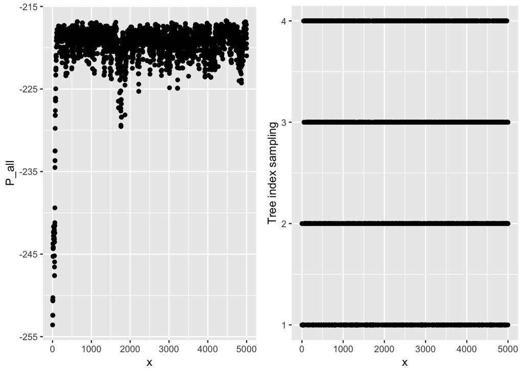

```r
dat_tmp <- data.frame(x=seq_len(length(rt_samp$P_all)), P_all=rt_samp$P_all,
                      tree_all=rt_samp$tree_all)

options(repr.plot.width=6, repr.plot.height=2)
fig1 <- ggplot(dat_tmp, aes(x=x, y=P_all)) + geom_point()
fig2 <- ggplot(dat_tmp, aes(x=x, y=tree_all)) + geom_point() + ylab("Tree index sampling")
ggarrange(fig1, fig2)
```

# 5 A simple tutorial example for MH sampling with discrete variable

```r
## a simple example for sampling discrete variable

P_target <- c(0.2, 0.1, 0.4, 0.3)

MH_sample <- function(K=4, n_iter=20, trans_mat=NULL){
    if(is.null(trans_mat)){
        trans_mat <- matrix(1.0/K, nrow=K, ncol=K)}

    P_all <- rep(0, n_iter)
    label_all <- rep(0, n_iter)
    accept_all <- rep(FALSE, n_iter)

    label_cur <- sample(K, size=1)
    P_cur <- P_target[label_cur]
    for(i in seq_len(n_iter)){
        #proposal a new state
        label_new <- sample(K, size=1, replace=T, prob=trans_mat[label_cur,])
        P_new <- P_target[label_new]
        Q_cur <- trans_mat[label_new, label_cur]
        Q_new <- trans_mat[label_cur, label_new]

        #accept ratio
        alpha <- min(1, (P_new * Q_cur) / (P_cur * Q_new))
        if (alpha >= runif(1, min = 0, max = 1)){
            P_all[i] <- P_new
            label_all[i] <- label_new
            accept_all[i] <- TRUE
            P_cur <- P_new
            label_cur <- label_new

        }else{
            label_all[i] <- label_cur
            P_all[i] <- P_cur
        }
    }
    return_list <- list(label_all=label_all, P_all=P_all, accept_all=accept_all)
    return_list
}
```

```r
n_iter = 1000
rt_samples <- MH_sample(n_iter = n_iter)
table(rt_samples$label_all[(n_iter/2+1):n_iter])
```

```
##
##   1   2   3   4
##  94  48 219 139
```

```r
mean(rt_samples$accept_all)
```

```
## [1] 0.759
```

```r
K = 4
test_mat <- matrix(sample(1000, size=K*K, replace=T), nrow=K, ncol=K)
test_mat <- test_mat / rowSums(test_mat)

adap_mat <- t(matrix(rep(table(rt_samples$label_all[(n_iter/2+1):n_iter]), K), nrow=K))
test_mat <- adap_mat / rowSums(adap_mat)

test_mat
```

```
##       [,1]  [,2]  [,3]  [,4]
## [1,] 0.188 0.096 0.438 0.278
## [2,] 0.188 0.096 0.438 0.278
## [3,] 0.188 0.096 0.438 0.278
## [4,] 0.188 0.096 0.438 0.278
```

```r
#rowSums(test_mat)

n_iter = 2000
rt_samples <- MH_sample(n_iter = n_iter, trans_mat = test_mat)
table(rt_samples$label_all[(n_iter/2+1):n_iter])
```

```
##
##   1   2   3   4
## 167 120 406 307
```

```r
mean(rt_samples$accept_all)
```

```
## [1] 0.9655
```